# ToothGrowth Data Analysis

Taedong Yun

## Overview

In this article, we will analyze the ToothGrowth data in the R datasets package. We will perform basic exploratory data analyses by providing a summary of the data and elementary statistical inference.

## Summary of Data

The ToothGrowth dataset contains the result of an experiment on Guinea Pigs about the correlation between Vitamin C dosage and the growth of tooth. Let us take a first look of the dataset.

```r
library(datasets)
str(ToothGrowth)
```

```
## 'data.frame':    60 obs. of  3 variables:
##  $ len : num  4.2 11.5 7.3 5.8 6.4 10 11.2 11.2 5.2 7 ...
##  $ supp: Factor w/ 2 levels "OJ","VC": 2 2 2 2 2 2 2 2 2 2 ...
##  $ dose: num  0.5 0.5 0.5 0.5 0.5 0.5 0.5 0.5 0.5 0.5 ...
```

The dataset has three variables, `len`, `supp`, and `dose`. `len` is the response which is the length of a tooth, `supp` is a delivery type of Vitamin C, swhich is either “VC” (ascorbic acid) or “OJ” (orange juice), and `dose` is the amount of dosage in milligrams. Note that `dose` variable take a value in 0.5, 1, or 2 so we can make it a factor variable. This dataset contains 60 observations. More information about this dataset can be found at https://stat.ethz.ch/R-manual/R-devel/library/datasets/html/ToothGrowth.html. Here is a basic summary of each variables in the dataset.

```r
ToothGrowth$dose <- as.factor(ToothGrowth$dose)
summary(ToothGrowth)
```

```
##       len        supp     dose
##  Min.   : 4.20   OJ:30   0.5:20
##  1st Qu.:13.07   VC:30   1  :20
##  Median :19.25           2  :20
##  Mean   :18.81
##  3rd Qu.:25.27
##  Max.   :33.90
```

Note that `supp` and `dose` factor variables are evenly distributed in their possible values. The following figure is a box plot of the dataset.

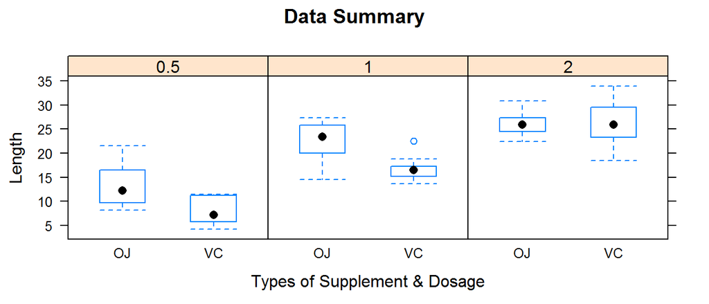

## Inference

From the boxplot in the previous section, we study the following the problems.

1. Do two different types of supplement have different effects on the growth of a tooth?
2. Does more dosage means more growth of a tooth?

We will address these two questions with simple T tests.

### Length vs Supplement Type

Given a null hypothesis that two different types of supplement have the *same* effect on the length of a tooth, we perform a two-sided T test against the variables `len` and `supp`. We assume unequal variance.

```r
t.test(len ~ supp, data = ToothGrowth, paired = FALSE, var.equal = FALSE)
```

```
##
##  Welch Two Sample t-test
##
## data:  len by supp
## t = 1.9153, df = 55.309, p-value = 0.06063
## alternative hypothesis: true difference in means is not equal to 0
## 95 percent confidence interval:
##  -0.1710156  7.5710156
## sample estimates:
## mean in group OJ mean in group VC
##         20.66333         16.96333
```

From the result of the test we can see that 95% confidence interval contains the value 0 (in other words the p-value is greater than 0.05). Hence, we **cannot** reject the null hypothesis.

### Length vs Dosage

For our second quesion, we will compare the differences of tooth length for dosage 0.5 and 1mg, and for 1 and 2mg. First we compare the dosage of 0.5 and 1mg. Our alternative hypothesis here is that the tooth length for 0.5mg dosage is *less* than the tooth length for 1mg dosage.

```r
suppressWarnings(library(dplyr))
TG1 <- filter(ToothGrowth, dose == 0.5 | dose == 1)
t.test(len ~ dose, data = TG1, paired = FALSE, var.equal = FALSE, alternative = "less")
```

```
##
##  Welch Two Sample t-test
##
## data:  len by dose
## t = -6.4766, df = 37.986, p-value = 6.342e-08
## alternative hypothesis: true difference in means is less than 0
## 95 percent confidence interval:
##       -Inf -6.753323
## sample estimates:
## mean in group 0.5   mean in group 1
##            10.605            19.735
```

Since the p-value is much less than 0.01, we can **reject** the null hypothesis and conclude that the tooth length for 0.5mg dosage is indeed less than the tooth length for 1mg dosage with 99% confidence.

Now let us compare 1mg and 2mg dosage with the same method.

```r
TG2 <- filter(ToothGrowth, dose == 1 | dose == 2)
t.test(len ~ dose, data = TG2, paired = FALSE, var.equal = FALSE, alternative = "less")
```

```
##
##  Welch Two Sample t-test
##
## data:  len by dose
## t = -4.9005, df = 37.101, p-value = 9.532e-06
## alternative hypothesis: true difference in means is less than 0
## 95 percent confidence interval:
##      -Inf -4.17387
## sample estimates:
## mean in group 1 mean in group 2
##          19.735          26.100
```

Again, the p-value is less than 0.01 so we **reject** the null hypothesis and conclude that more dosage means more growth with 99% confidence.